# HW3

Sonya Hua

October 15, 2017

### Problem 2.2

1. Add another component to the regression in (2.25) that accounts for the particulate count 4 weeks prior. State your conclusion

```r
# ------------------------------------------------------------------------------------
# Pollution, temperature and mortality
library(astsa)
data(cmort); data(tempr); data(part)


data2=ts.intersect(cmort, tempr, part, partL4=lag(part,-4), dframe=TRUE)  # lag particulates by 4 weeks
temp=data2$tempr-mean(data2$tempr) # center temperature
temp2=data2$temp^2
trend=time(data2$cmort) # time
fit=lm(cmort~trend+temp+temp2+part+partL4, data=data2, na.action=NULL)
summary(fit) # regression results
```

```
##
## Call:
## lm(formula = cmort ~ trend + temp + temp2 + part + partL4, data = data2,
##     na.action = NULL)
##
## Residuals:
##     Min      1Q  Median      3Q     Max
## -18.228  -4.314  -0.614   3.713  27.800
##
## Coefficients:
##               Estimate Std. Error t value Pr(>|t|)
## (Intercept)  2.689e+03  2.001e+02  13.440  < 2e-16 ***
## trend       -1.385e+00  1.006e-01 -13.765  < 2e-16 ***
## temp        -3.606e+00  4.218e-01  -8.549  < 2e-16 ***
## temp2        2.155e-02  2.803e-03   7.688 8.02e-14 ***
## part         2.029e-01  2.266e-02   8.954  < 2e-16 ***
## partL4       1.030e-01  2.485e-02   4.147 3.96e-05 ***
## ---
## Signif. codes:  0 '***' 0.001 '**' 0.01 '*' 0.05 '.' 0.1 ' ' 1
##
## Residual standard error: 6.287 on 498 degrees of freedom
## Multiple R-squared:  0.608,  Adjusted R-squared:  0.6041
## F-statistic: 154.5 on 5 and 498 DF,  p-value: < 2.2e-16
```

**State your Conclusion**: When lagging particulates by 4 weeks, there is a significant predictive ability of mortality rates for particulates 4 weeks in advance. P-value for partL4 is significant at p < 0.05 level. The model explains ~60% of the variance found in the data with an adjusted r-quare of 0.6041.

```r
#install.packages("picante")
library(picante)
#Insert the name of your dataset in the code below
correlation <- cor.table(data2, cor.method="pearson")
correlation$r
```

```
##             cmort      tempr       part     partL4
## cmort   1.0000000 -0.4369648  0.4422896  0.5209993
## tempr  -0.4369648  1.0000000 -0.0148241 -0.3990848
## part    0.4422896 -0.0148241  1.0000000  0.5340505
## partL4  0.5209993 -0.3990848  0.5340505  1.0000000
```

### Problem 2.8

1. Argue that the glacial vares series exhibits heteroscedasticity by computing the sample variance over the first half and the second half of the data.

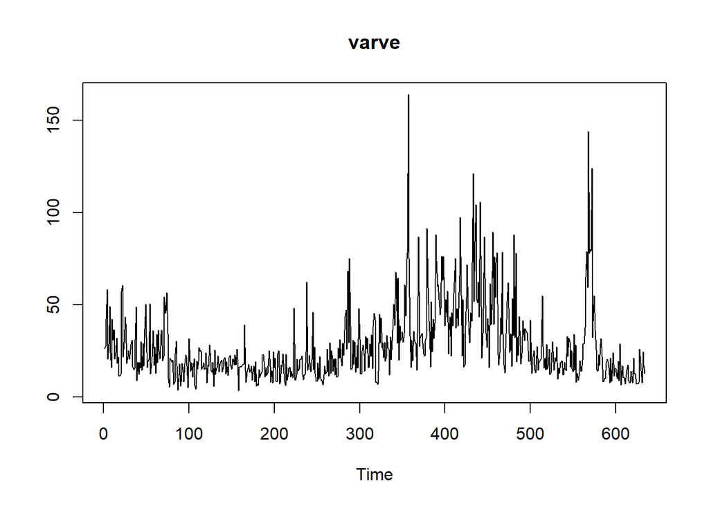

```r
data(varve)
plot(varve,main="varve",ylab="")
```

```r
# Compute sample variances of first half and second half
var(varve[1:317])   # Variance of first half of varve series
```

```
## [1] 133.4574
```

```r
var(varve[318:length(varve)]) # Variance of second half
```

```
## [1] 594.4904
```

**Argument** : Observe the notably larger variance in the 2nd half of the varve series (variance = 594) vs. the first half of the series (variance = 133). The time series plot also shows a noticeably larger variance in the second half of the time series.

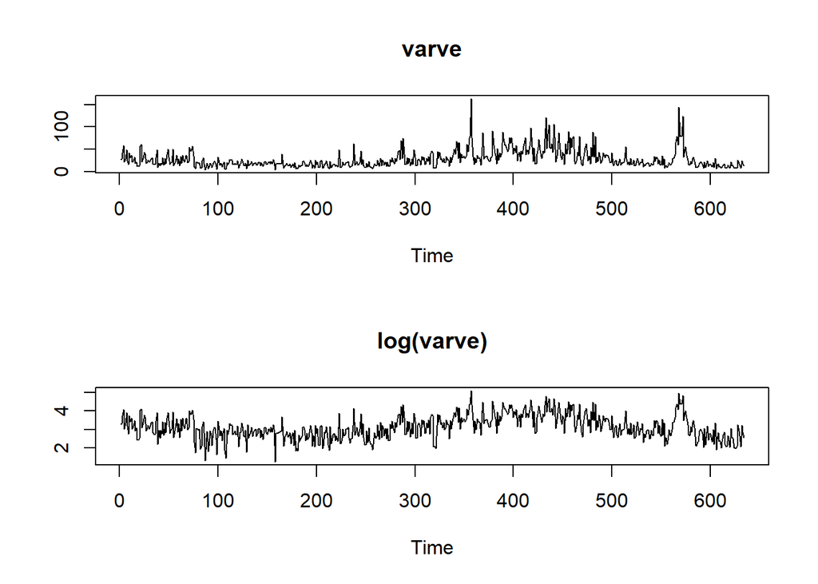

```r
data(varve)
par(mfrow=c(2,1))
plot(varve,main="varve",ylab="")
plot(log(varve),main="log(varve)",ylab="" )
```

**Argue that the log transformation stabilizes the variance over the series:** As seen in above plots of before vs. after log transformation, we see a flatter variance in the log transformation compared to series without transformation. It has stabilized the variance more after log transformation as the series seems to stabilize around the value 3.

Plot the histograms of glacial varves series and log-transformation of the glacial vares series to see whether the approximation to normality is improved by transforming the data

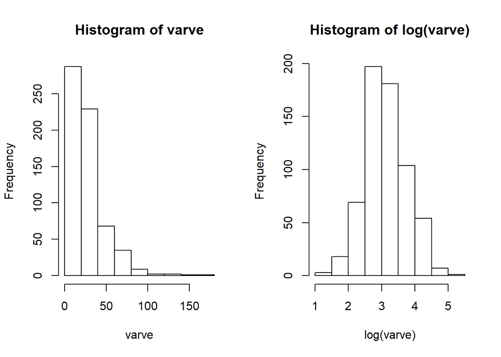

```r
par(mfrow=c(1,2))
hist(varve)
hist(log(varve))
```

2. Plot the series yt (log of xt). Do any time intervals of the order 100 yrs, exist where one can observe behavior comparable to that observed in the gloabl temperature records in Figure 1.2?

**Answer** Please see plot above. At time = 300, we can observe behavior comparable to that observed in Figure 1.2, where there is an upward trend in the series, and a leveling off at time = 450 , then a sharp upward trend at about time = 550.

3. Examine the sample ACF of yt and comment

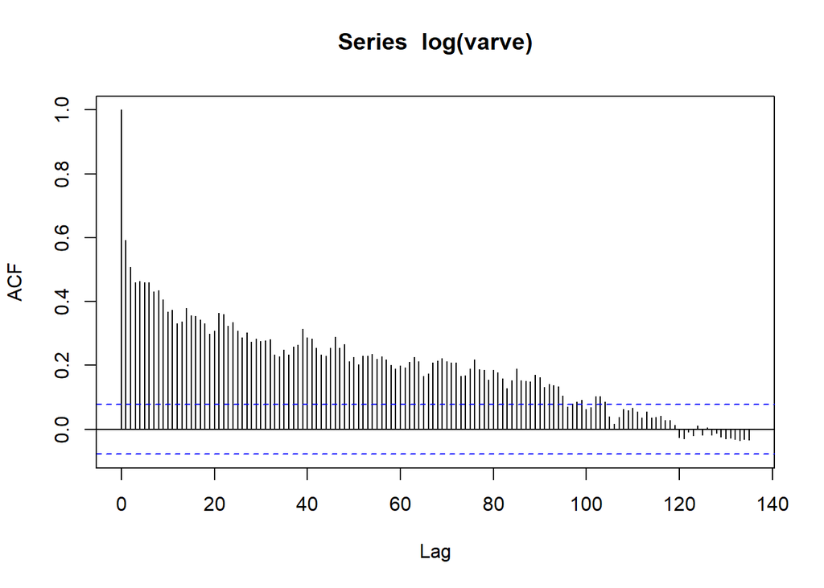

```r
acf(log(varve),135)
```

4. Compute the difference (ut) by differencing in the first order, examine its time plot and Sample ACF, and argue that differencing hte logged varve data produces a reasonably stationary series.

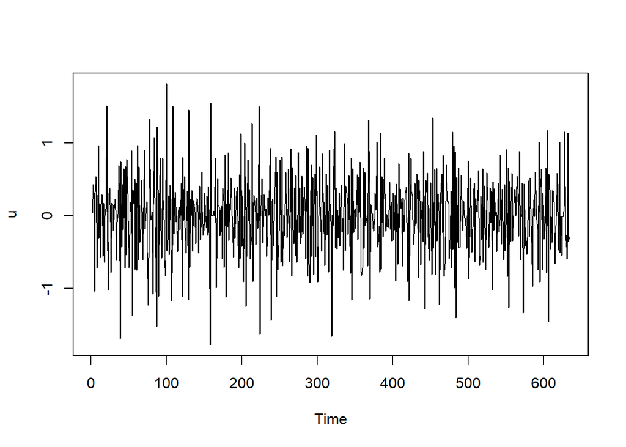

```r
u = diff(log(varve), 1)
plot(u)
```

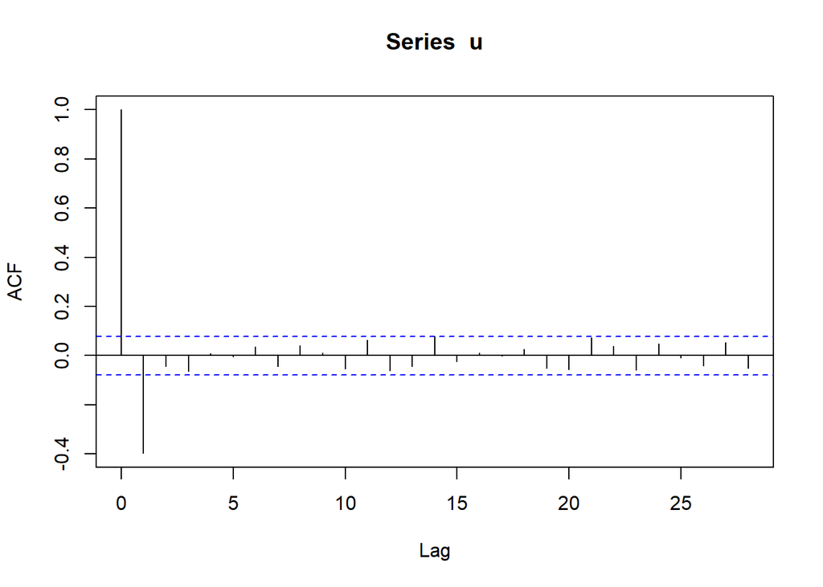

```r
acf(u)
```

**Argument** Notice that we do not see any significant trends after differencing the log-transformed varve series whereas before, we saw an upward trend around time=300 and a sharp upward trend after time=500. The plot shows a more stationary time series. A practical interpretion for ut the annual change in varve thickness.